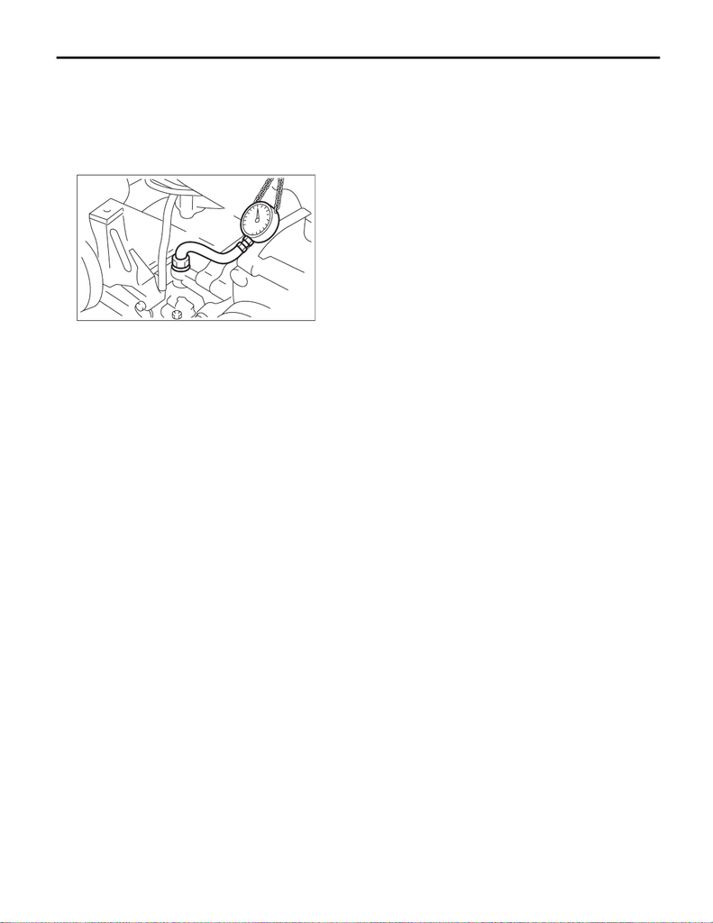

Engine Oil Pressure

MECHANICAL

6. Engine Oil Pressure

A: INSPECTION

1) Disconnect the ground cable from battery.

2) Remove the oil pressure switch. <Ref. to

LU(STI)-22, REMOVAL, Oil Pressure Switch.>

3) Install the oil pressure gauge to cylinder block.

STALLATION, Generator.>

5) Connect the battery ground terminal.

6) Start the engine, and check the oil pressure.

NOTE:

• Standard value is based on an engine oil temper-

ature of 80°C (176°F).

• If the oil pressure is out of specification, check oil

pump, oil filter and lubrication line. <Ref. to

LU(STI)-30, INSPECTION, Engine Lubrication

System Trouble in General.>

• If the oil pressure warning light is ON and oil

pressure is within specification, check the oil pres-

sure switch. <Ref. to LU(STI)-30, INSPECTION,

Engine Lubrication System Trouble in General.>

Engine oil pressure:

Standard

98 kPa (1.0 kg/cm

, 14 psi) or more (at 600

rpm)

392 kPa (4.0 kg/cm

, 57 psi) or more (at

6,000 rpm)

7) After inspection, install the related parts in the

reverse order of removal.

ME-03698